# Exposure

## Risk benefit assessment of iodization of salt in Norway.

This page is meant as a methodological online appendix to the exposure and scenario calculations for the project “Benefit and risk assessment of iodization of household salt and salt used in bread and bakery products”. This page has two purposes; document the approach used in the report and to aid others in understanding and possibly using this approach for their own projects.

The terms of reference for the project can be found [here](https://vkm.no/download/18.4965dafe1629d0b5ea58f256/1523625764316/Bestilling%20nytte-%20og%20risikovurdering%20av%20jodberikning.pdf). The final report will be linked to [here](https://vkm.no)

The Risk-Benefit assessment itself has been scrutinized and approved by the Norwegian Scientific Committee in addition to having been reviewed by three experts outside the project group. This page, however, has been through far less scrutiny and may contain errors.

## Prerequisites

Some basic understanding of the functioning of R is needed to follow this document. Excellent introductions to the software, as well as the usage of Rstudio is available online.

To perform this analysis in `R`, a few packages needs to be installed, minimally the package `MCMCglmm`.

## Reading/compiling the data

The underlying data for the modelling are either intake data or covariates for the individuals in the survey. The intake data is calculated in the Norwegian Dietary Calculation System (KBS) and consists of daily intakes of iodine through diet (either including or exlucing supplements) and consumption of bread. For Norkost 3 (adults), two reported days are included and for Ungkost (4,9 and 13 year olds) 4 consecutive days are included.

All surveys are to a certain degree not representative of the population they are used to estimate the intake for. We are interested in the long-term (chronic) intake for the general Norwegian population, but we know that Norkost is slightly unrepresentative in that it has a higher proportion of respondents with a high level of education. We will estimate the effect of this so we can (to a certain degree at least) correct for this unrepresentativeness. If, for instance, highly educated individuals on average have a higher intake of iodine, neglecting to correct for this bias will lead to overestimation of the overall iodine intake for the Norwegian population.

In addition to level of education we expect iodine intakes to be dependent on sex and age, and include these as covariates in our models. For Ungkost, age and level of education are fixed for each age-group and are not included in the modelling. Only Norkost will be presented to exemplify the approach. Ungkost is in structure similar, but differs in that it has fewer covariates, but more sampled days.

All intakes and covariates are compiled into a data.frame with a row for each individual-day. So for Norkost 3, with 1787 individuals participating, the data.frame has 3574 rows. Each row as an individual identifier (`$ind`), `$sex`, `$wgt` (weight), `$day` (a or b), `$age`, `$educ` (level of education 0 means some time in college og university, 1 - no studies in college/university), `$bread` (consumption of bread), `$iodine_wS` (iodine intake including supplements) and `$iodine_woS` (iodine without supplements). `$iod_y` is only a mock variable used for programming purposes.

## A quick look at the data and a simple model.

To get a quick overview of the structure of the data;

```r
head(dataNK3)
```

```
##     ind    sex wgt day age educ bread iodine_wS iodine_woS  iod_y
## 1 11001 female  63   a  60    0  46.0    468.13     468.13 468.13
## 2 11003   male  82   a  32    0 172.8     46.32      46.32  46.32
## 3 11005 female  85   a  39    0  60.0     18.88      18.88  18.88
## 4 11006   male  99   a  63    0 120.0     70.45      70.45  70.45
## 5 11007   male  78   a  36    0 405.0    134.28     134.28 134.28
## 6 11008   male 101   a  36    0 142.0    360.03     288.03 288.03
```

The main goal of doing mixed models on dietary intake data is to decompose the variance in intakes into variance between individuals and variance within individuals. We are trying to use the surveys to estimate the long-term intakes, and thus ‘remove’ the variance within individuals, i.e. the day-to-day variation. In practice this is done by introducing random effects for individuals. The simplest model, will be this `model1 <- MCMCglmm(log(iodine_woS)~1, random=~ind, data=dataNK3)`

In this model the mean log iodine intake will be modelled, including a ‘random effect’ for each individual and a residual for each day. Here we have no covariate (the model formula is `~1`), and have set `~ind` as random effect.

Then a summary of this model can be shown.

```r
summary(model1)
```

```
##
##  Iterations = 3001:12991
##  Thinning interval  = 10
##  Sample size  = 1000
##
##  DIC: 8839.312
##
##  G-structure:  ~ind
##
##     post.mean l-95% CI u-95% CI eff.samp
## ind    0.1909   0.1513    0.228    447.4
##
##  R-structure:  ~units
##
##       post.mean l-95% CI u-95% CI eff.samp
## units    0.5678   0.5263   0.6051    990.5
##
##  Location effects: log(iodine_woS) ~ 1
##
##             post.mean l-95% CI u-95% CI eff.samp  pMCMC
## (Intercept)     4.795    4.763    4.825     1300 <0.001 ***
## ---
## Signif. codes:  0 '***' 0.001 '**' 0.01 '*' 0.05 '.' 0.1 ' ' 1
```

The three main parts of a model fit are, in MCMCglmm terms, called the `G-structure`, the `R-structure` and the `Location effects`. The first is the estimated variance of the random effects, i.e. to which degree individuals differ among themselves in their usual (log) intake. The `R-structure` is the residuals, i.e. to which degree individuals varies in intake from day to day. The `Location effects` deal with the overall mean.

This is a simple model of daily intakes, and the `(Intercept)` parameter is estimated to be around 4.8 on a log scale, i.e. approximately 121 µg in daily intakes. It is crucial to understand what this number is; it is not long-term intake for the population, it is the expectation of the log(intake) for any single day. Since intake is skewed, and bounded by 0, the long-term intake will be higher. This is a fundamental aspect of transforming the modelled intake from real to log (as we do here), or by any other power-function (as the Cox-transformation).

### Extracting a long-term intake

So if we want to ‘simulate’ a new individuals iodine intake, we then use the estimated parameters. Firstly we use the `(Intercept)`, which is `4.796`. Then we add a deviation from this, i.e. we sample a new ‘random effect’ using the estimated distribution of random effects. In the example here the `ind` is approximately 0.19, i.e. individuals are (on the log scale) estimated to differ among eachother following a normal distribution with mean 0 and a variance of 0.19. Drawing one random number from such a normal distribution then yields a ‘simulated’ mean daily intake for a particular individual. Now we have one individual’s expected log intake. Next step is to simulate the realized daily intakes. The model have estimated that the day-to-day variance in intakes is about 0.57. In our approach we set a long-term intake to be over 365 simulated days. The reason why we draw this many days is that we want the long-term intake for each simulated individual on the **real** scale, and since the day-to-day variation is normal on the log-scale, it is not just the exponentiated estimated paramter (the mean of the log of x is not the same as the log of the mean, remember?).

So if we want the long-term intake predicted by this model fit we need to sample the estimated parameters (the whole thing is Bayesian), then use these parameters to ‘simulate’ individuals (with a drawn ‘random effect’) and draw a large number of days for each simulated individuals. Then we have a set of daily intake on a log scale, and the mean of these on the real scale is thus mean(exp(log_intakes)).

In `R` we construct a function that takes a fitted simple model as input (`mcmc_fit`), and the number of individual (`n_ind`, default is 100, i.e. if we don’t give a different number when we call this function it will simulate 100), and number of days over which we want the long-term mean (`n_days`).

```r
drawIod <- function(mcmc_fit,n_ind=100,n_days=365){
  # A quick function used to sample from a fitted MCMCglmm model with no covariates and simple
  # random effects.
  xi <- sample(dim(mcmc_fit$Sol)[1],n_ind,replace=T);
  # This is just a sampled index into the array of estimated parameters in the Bayesian output from the model (X)
  iod <- array(NA,n_ind)
  for (ii in 1:n_ind){
    # Loop over all individuals.
    # exp(Sampled (intercept) + Randomly drawn Individual level random effect + n_days number of residuals)
    iod[ii] <- mean(exp(mcmc_fit$Sol[xi[ii]] + rnorm(1,mean=0,sd=sqrt(mcmc_fit$VCV[xi[ii],1])) +
                          rnorm(n_days,mean=0,sd=sqrt(mcmc_fit$VCV[xi[ii],2]))))
  }
  return(iod)
}
```

So this function(`drawIod`) can be called to simulated mean intakes for any number of simulated individuals over any number of days. We can calculate the Observed Individual Mean (OIM) of the intake, and see how the distributions compare when simulating the same number of individuals (n=1787) and two days.

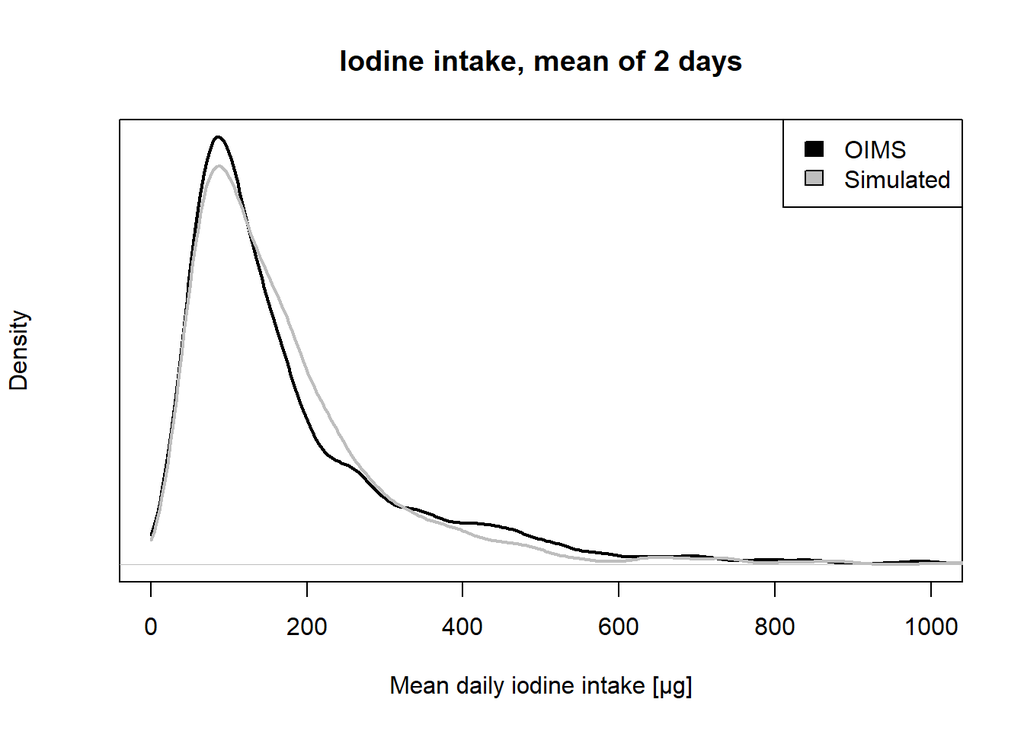

```r
# Calculating the observed individual means.
oims <- sapply(unique(dataNK3$ind),function(ii){mean(dataNK3[which(dataNK3$ind==ii),]$iodine_woS)});
# Simulating 1787 individuals, with 2 days each.
simulated_2days <- drawIod(model1,n_ind=1787,n_days=2);
plot(density(oims,from=0),xlim=c(0,1000),main='Iodine intake, mean of 2 days',xlab='Mean daily iodine intake [µg]',lwd=2,yaxt='n')
lines(density(simulated_2days,from=0),col='grey',lwd=2);
legend('topright',fill=c('black','grey'),legend=c('OIMS','Simulated'))
```

This figure shows a smoothed distribution of the calculated observed individual means (OIMs) and simulated intakes for the same number of individuals over 2 days using the fitted model.

### Getting long-term intake.

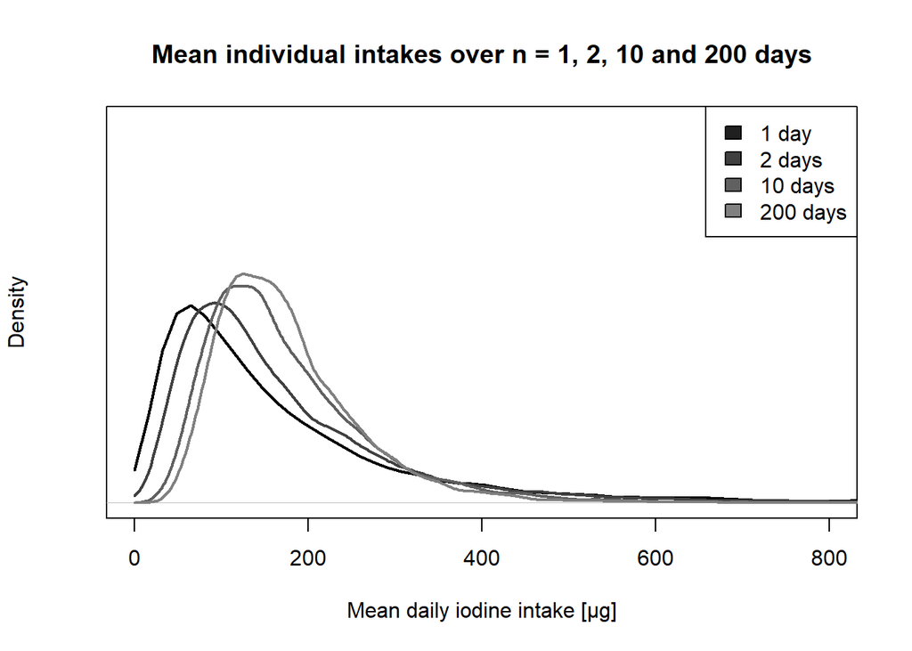

```r
sim_days <- sapply(c(1,2,10,200),function(ii){drawIod(model1,n_ind=1e4,n_days=ii)});
plot(density(sim_days[,1],from=0),xlim=c(0,800),ylim=c(0,0.01),main='Mean individual intakes over n = 1, 2, 10 and 200 days',yaxt='n',xlab='Mean daily iodine intake [µg]',lwd=2)
for (ii in 2:4){lines(density(sim_days[,ii],from=0),col=rgb(ii/8,ii/8,ii/8),lwd=2)}
legend('topright',legend=c('1 day','2 days','10 days','200 days'),fill=sapply(1:4,function(ii){rgb(ii/8,ii/8,ii/8)}))
```

We can also quickly look at some percentiles of these simulations. The tails are becoming narrower (as expected). Please note that this is not a particularly good model of the data, and was explicitly made simple for exposition of the usage of MCMCglmm and R to make the estimates.

|  | 5% | 50% | 95% |
| --- | --- | --- | --- |
| 1 day | 28 | 120 | 506 |
| 2 day | 43 | 135 | 440 |
| 10 days | 67 | 153 | 362 |
| 200 days | 78 | 160 | 332 |

## Building up with covariates.

Does the daily intakes of iodine and bread differ between the sexes? A quick boxplot of the raw daily intakes shows that it looks like it does.

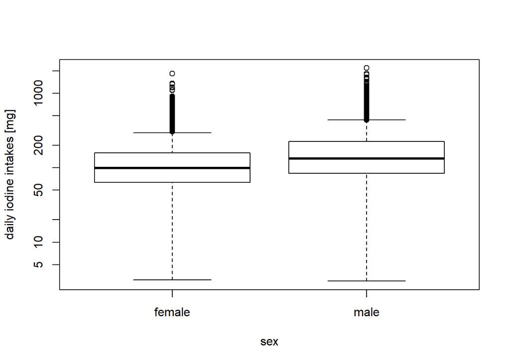

So how can we take sex into account, and how does sex really matter? If we only include sex into the model, there are in fact three ways in which it could enter: * As a fixed effect, i.e. that males and females have different mean log daily intakes. * As structuring the random effects, i.e. that males differ between individuals in a different ways than females. * As structuring the residuals, i.e. that males have a different day-to-day variance in intakes than females.

Below shows how to make these changes to fit a MCMCglmm model, first only adding a fixed effect (`model2a`), then a fixed effect and random effects that can differ between males and females (`model2b`) and finally a model where the residuals (day to day variation) also differs between the sexes (`model2c`).

```r
model2a <- MCMCglmm(log(iodine_woS)~sex,random=~ind,data=dataNK3)
model2b <- MCMCglmm(log(iodine_woS)~sex,random=~idh(sex):ind,data=dataNK3)
model2c <- MCMCglmm(log(iodine_woS)~sex,random=~idh(sex):ind,
                    rcov=~idh(sex):units,data=dataNK3)
```

When looking at the summary of this last model with all possible structuring by sex, we see that males have a higher intake overall. The fixed effect `sexmale` listed in under the heading `Location effects` is approximately 0.3. This means that on a log scale males have a mean log intake 0.3 higher than females, and since this is on the log scale males have about 34 percent higher intakes of iodine.

```r
summary(model2c)
```

```
##
##  Iterations = 3001:12991
##  Thinning interval  = 10
##  Sample size  = 1000
##
##  DIC: 8793.735
##
##  G-structure:  ~idh(sex):ind
##
##               post.mean l-95% CI u-95% CI eff.samp
## sexfemale.ind    0.1479   0.0971   0.1953    240.6
## sexmale.ind      0.1885   0.1358   0.2378    582.8
##
##  R-structure:  ~idh(sex):units
##
##                 post.mean l-95% CI u-95% CI eff.samp
## sexfemale.units    0.5556   0.5038    0.611    382.1
## sexmale.units      0.5867   0.5364    0.644    851.1
##
##  Location effects: log(iodine_woS) ~ sex
##
##             post.mean l-95% CI u-95% CI eff.samp  pMCMC
## (Intercept)    4.6550   4.6141   4.6996     1000 <0.001 ***
## sexmale        0.2900   0.2310   0.3558     1086 <0.001 ***
## ---
## Signif. codes:  0 '***' 0.001 '**' 0.01 '*' 0.05 '.' 0.1 ' ' 1
```

The other estimated parameters indicate that not only do males have a higher iodine intake than females on average, but they also have a larger degree of variability between individuals (`sexmale.ind` has a posterior mean `post.mean` of about 0.19, wherease for females it is about 0.15). There is also a slight indication that the variance within individuals (`sexmale.units` vs `sexfemale.units`) is also higher for males. Plotting the estimated means and variance also show this;

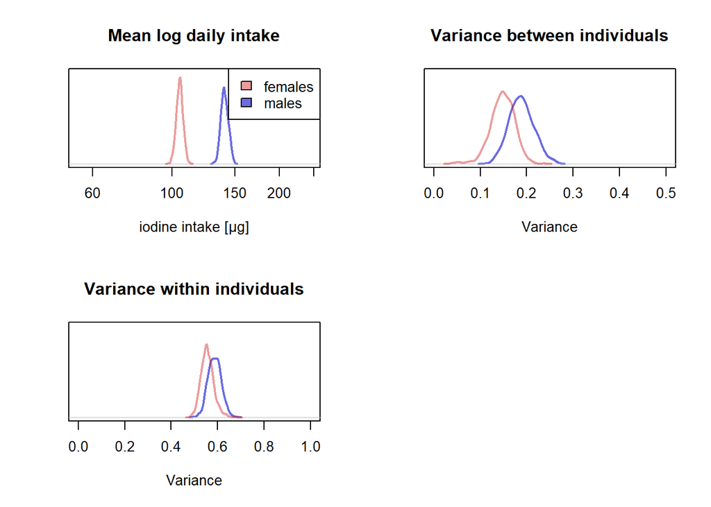

To arrive at long-term intakes from this mode complex model with differences between the sexes, a new function to sample the parameters and draw both the individual level random effects and day-to-day variations must be generated.

## The full model for iodine intake.

The model used to estimate the long-term intake also included age as a fixed effect as well as level of education. This allows us to correct (to a certain degree) for the unrepresentativeness of the underlying data. By quantifying how much higher/lower the intake is for highly educated individuals, we can make a simulation function that corrects for this by drawing intakes for a target population more similar to the real Norwegian population. Similarly for age.

The full univariate model we used for this project was;

```r
model3 <- MCMCglmm(log(iodine_woS) ~ sex + age + educ,
                   random = ~idh(sex):ind,
                   rcov  = ~idh(sex):units,
                   data = dataNK3)
```

And the summary;

```r
summary(model3)
```

```
##
##  Iterations = 3001:12991
##  Thinning interval  = 10
##  Sample size  = 1000
##
##  DIC: 8780.328
##
##  G-structure:  ~idh(sex):ind
##
##               post.mean l-95% CI u-95% CI eff.samp
## sexfemale.ind    0.1411  0.09284   0.1870    355.6
## sexmale.ind      0.1837  0.12510   0.2406    365.5
##
##  R-structure:  ~idh(sex):units
##
##                 post.mean l-95% CI u-95% CI eff.samp
## sexfemale.units    0.5557   0.5081   0.6131    517.6
## sexmale.units      0.5857   0.5326   0.6456    668.9
##
##  Location effects: log(iodine_woS) ~ sex + age + educ
##
##             post.mean  l-95% CI  u-95% CI eff.samp  pMCMC
## (Intercept)  4.409740  4.313411  4.529288     1000 <0.001 ***
## sexmale      0.281959  0.223283  0.347323     1000 <0.001 ***
## age          0.005771  0.003772  0.007948     1000 <0.001 ***
## educ1       -0.032954 -0.093271  0.025840     1000  0.294
## ---
## Signif. codes:  0 '***' 0.001 '**' 0.01 '*' 0.05 '.' 0.1 ' ' 1
```